# NbClust - Determine Optimal Number of Clusters

Clustering is the partitioning of a set of objects into groups (clusters) so that objects within a group are more similar to each others than objects in different groups. Most of the clustering algorithms depend on some assumptions in order to define the subgroups present in a data set. As a consequence, the resulting clustering scheme requires some sort of evaluation as regards its validity.

The evaluation procedure has to tackle difficult problems such as the quality of clusters, the degree with which a clustering scheme fits a specific data set and the optimal number of clusters in a partitioning. In the literature, a wide variety of indices have been proposed to find the optimal number of clusters in a partitioning of a data set during the clustering process. However, for most of indices proposed in the literature, programs are unavailable to test these indices and compare them.

The [R package **NbClust**](https://cran.r-project.org/web/packages/NbClust/NbClust.pdf) has been developed for that purpose. It provides 30 indices which determine the number of clusters in a data set and it offers also the best clustering scheme from different results to the user. In addition, it provides a function to perform k-means and hierarchical clustering with different distance measures and aggregation methods. Any combination of validation indices and clustering methods can be requested in a single function call. This enables the user to simultaneously evaluate several clustering schemes while varying the number of clusters, to help determining the most appropriate number of clusters for the data set of interest.

### Examples

#### Simulated Data Example

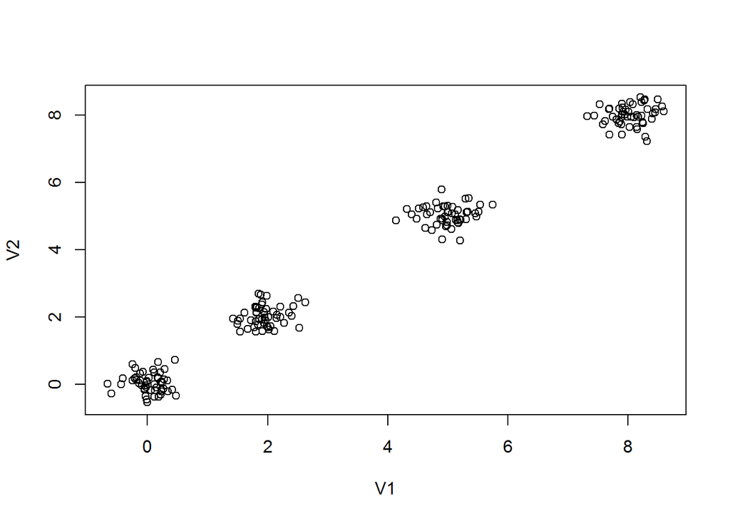

```r
data <- read.table("./ML/data/SimulatedData.txt", header = TRUE, quote = "\"")
plot(data)
```

```r
res <- NbClust(data, distance = "euclidean", min.nc = 2, max.nc = 8, method = "ward.D2",
               index = "duda")
res$All.index
```

```
##      2      3      4      5      6      7      8
## 0.0388 0.0738 0.5971 0.6691 0.6602 0.6210 0.4200
```

```r
res$Best.nc
```

```
## Number_clusters     Value_Index
##          4.0000          0.5971
```

```r
res$All.CriticalValues
```

```
##      2      3      4      5      6      7      8
## 0.4349 0.4349 0.3327 0.3327 0.3327 0.3327 0.2234
```

```r
res$Best.partition
```

```
##   [1] 1 1 1 1 1 1 1 1 1 1 1 1 1 1 1 1 1 1 1 1 1 1 1 1 1 1 1 1 1 1 1 1 1 1 1
##  [36] 1 1 1 1 1 1 1 1 1 1 1 1 1 1 1 2 2 2 2 2 2 2 2 2 2 2 2 2 2 2 2 2 2 2 2
##  [71] 2 2 2 2 2 2 2 2 2 2 2 2 2 2 2 2 2 2 2 2 2 2 2 2 2 2 2 2 2 2 3 3 3 3 3
## [106] 3 3 3 3 3 3 3 3 3 3 3 3 3 3 3 3 3 3 3 3 3 3 3 3 3 3 3 3 3 3 3 3 3 3 3
## [141] 3 3 3 3 3 3 3 3 3 3 4 4 4 4 4 4 4 4 4 4 4 4 4 4 4 4 4 4 4 4 4 4 4 4 4
## [176] 4 4 4 4 4 4 4 4 4 4 4 4 4 4 4 4 4 4 4 4 4 4 4 4 4
```

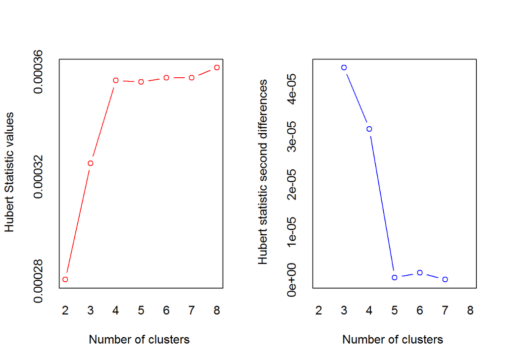

```
## *** : The Hubert index is a graphical method of determining the number of clusters.
##                 In the plot of Hubert index, we seek a significant knee that corresponds to a
##                 significant increase of the value of the measure i.e the significant peak in Hubert
##                 index second differences plot.
##
```

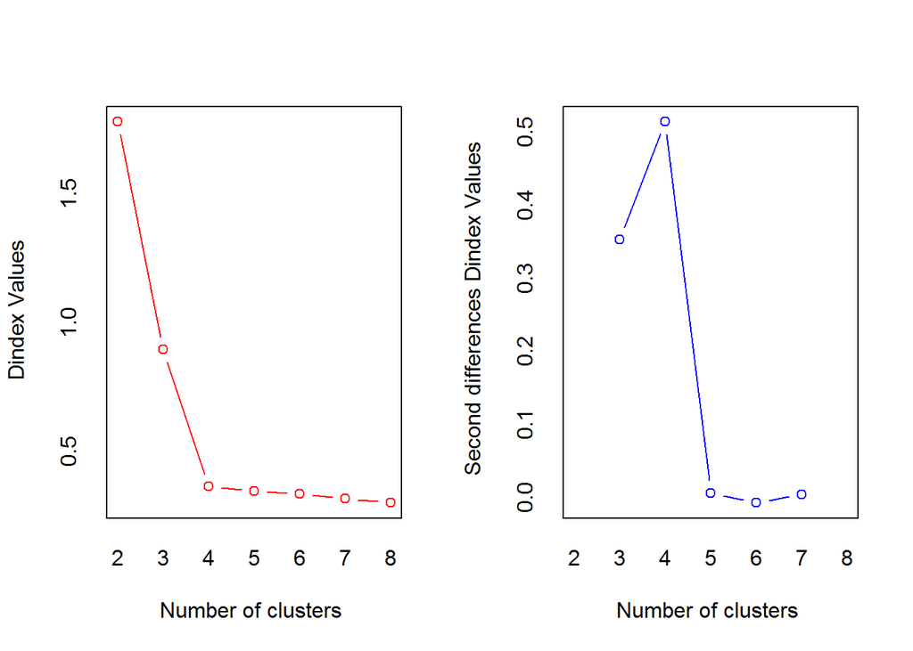

```
## *** : The D index is a graphical method of determining the number of clusters.
##                 In the plot of D index, we seek a significant knee (the significant peak in Dindex
##                 second differences plot) that corresponds to a significant increase of the value of
##                 the measure.
##
## * Among all indices:
## * 3 proposed 2 as the best number of clusters
## * 4 proposed 3 as the best number of clusters
## * 19 proposed 4 as the best number of clusters
## * 1 proposed 5 as the best number of clusters
##
##                    ***** Conclusion *****
##
## * According to the majority rule, the best number of clusters is  4
##
##
```

```r
res <- NbClust(data, distance = "euclidean", min.nc = 2, max.nc = 8, method = "complete",
               index = "alllong")
```

```r
res$All.index
```

```
##        KL        CH  Hartigan     CCC     Scott   Marriot   TrCovW
## 2  3.4594  885.3975  398.1129 17.3825  530.5325 39798.188 228.9249
## 3  1.2566 1524.1400 1126.0955 17.4487  761.9166 28157.985 237.8424
## 4 26.9498 7163.1259   17.0799 30.6642 1247.1374  4424.207 223.0371
## 5  0.9651 5814.9538   11.1679 26.0102 1287.0337  5662.677 151.7204
## 6  2.7236 4895.3856   22.8628 22.4624 1306.3867  7402.183 145.2914
## 7  2.1804 4540.5372   23.4182 20.3053 1351.0258  8059.734 123.0103
## 8  1.2075 4344.8386   20.6834 18.7214 1403.6219  8092.706 106.9838
##     TraceW Friedman    Rubin Cindex     DB Silhouette   Duda  Pseudot2
## 2 676.8594 295.4549  13.8329 0.3601 0.4635     0.7209 0.0388 2430.0879
## 3 224.8201 328.3267  41.6464 0.3043 0.2878     0.7794 0.0738 1230.0792
## 4  33.4742 564.6962 279.7063 0.3058 0.2415     0.8441 0.7175   18.9003
## 5  30.7910 634.2843 304.0806 0.3428 0.7714     0.6948 0.7679   14.5044
## 6  29.1231 661.0045 321.4956 0.3515 0.9099     0.5547 0.6189   29.5544
## 7  26.0528 739.4890 359.3836 0.3425 1.0936     0.4442 0.6772   22.8848
```

[output cut: 17 more lines]

```r
res$Best.nc
```

```
##                      KL       CH Hartigan     CCC    Scott  Marriot
## Number_clusters  4.0000    4.000    4.000  4.0000   4.0000     4.00
## Value_Index     26.9498 7163.126 1109.016 30.6642 485.2208 24972.25
##                  TrCovW   TraceW Friedman     Rubin Cindex     DB
## Number_clusters  5.0000   3.0000   4.0000    4.0000 3.0000 4.0000
## Value_Index     71.3167 260.6934 236.3695 -213.6856 0.3043 0.2415
##                 Silhouette   Duda PseudoT2  Beale Ratkowsky     Ball
## Number_clusters     4.0000 4.0000   4.0000 4.0000    2.0000   3.0000
## Value_Index         0.8441 0.7175  18.9003 0.3857    0.6392 263.4897
##                 PtBiserial    Gap Frey McClain Gamma  Gplus      Tau
## Number_clusters     2.0000 4.0000    1  4.0000     4 4.0000    2.000
## Value_Index         0.8002 1.7257   NA  0.2496     1 0.0011 4664.155
##                   Dunn Hubert SDindex Dindex   SDbw
## Number_clusters 4.0000      0  3.0000      0 4.0000
## Value_Index     0.8184      0  0.7843      0 0.0091
```

```r
res$All.CriticalValues
```

```
##   CritValue_Duda CritValue_PseudoT2 Fvalue_Beale CritValue_Gap
## 2         0.4349           127.3323       0.0000       -0.2859
## 3         0.4349           127.3323       0.0000       -1.3651
## 4         0.3327            96.2763       0.6810        0.3531
## 5         0.3327            96.2763       0.7445        0.4008
## 6         0.3327            96.2763       0.5491        0.1166
## 7         0.3327            96.2763       0.6283        0.2139
## 8         0.2234            93.8395       0.3727        0.1015
```

```r
res$Best.partition
```

```
##   [1] 1 1 1 1 1 1 1 1 1 1 1 1 1 1 1 1 1 1 1 1 1 1 1 1 1 1 1 1 1 1 1 1 1 1 1
##  [36] 1 1 1 1 1 1 1 1 1 1 1 1 1 1 1 2 2 2 2 2 2 2 2 2 2 2 2 2 2 2 2 2 2 2 2
##  [71] 2 2 2 2 2 2 2 2 2 2 2 2 2 2 2 2 2 2 2 2 2 2 2 2 2 2 2 2 2 2 3 3 3 3 3
## [106] 3 3 3 3 3 3 3 3 3 3 3 3 3 3 3 3 3 3 3 3 3 3 3 3 3 3 3 3 3 3 3 3 3 3 3
## [141] 3 3 3 3 3 3 3 3 3 3 4 4 4 4 4 4 4 4 4 4 4 4 4 4 4 4 4 4 4 4 4 4 4 4 4
## [176] 4 4 4 4 4 4 4 4 4 4 4 4 4 4 4 4 4 4 4 4 4 4 4 4 4
```

#### Simulated Data Example 2

```r
set.seed(1)
y <- rbind(matrix(rnorm(150,sd = 0.3),ncol = 3),
           matrix(rnorm(150,mean = 3,sd = 0.2),ncol = 3),
           matrix(rnorm(150,mean = 5,sd = 0.3),ncol = 3))
diss_matrix <-  dist(y, method = "euclidean", diag = FALSE)
res <- NbClust(y, diss = diss_matrix, distance = NULL, min.nc = 2, max.nc = 6,
               method = "average", index = "ch")

res$All.index
```

```
##         2         3         4         5         6
##  721.3436 4490.9857 3080.0133 2345.5167 2011.6524
```

```r
res$Best.nc
```

```
## Number_clusters     Value_Index
##           3.000        4490.986
```

```r
res$Best.partition
```

```
##   [1] 1 1 1 1 1 1 1 1 1 1 1 1 1 1 1 1 1 1 1 1 1 1 1 1 1 1 1 1 1 1 1 1 1 1 1
##  [36] 1 1 1 1 1 1 1 1 1 1 1 1 1 1 1 2 2 2 2 2 2 2 2 2 2 2 2 2 2 2 2 2 2 2 2
##  [71] 2 2 2 2 2 2 2 2 2 2 2 2 2 2 2 2 2 2 2 2 2 2 2 2 2 2 2 2 2 2 3 3 3 3 3
## [106] 3 3 3 3 3 3 3 3 3 3 3 3 3 3 3 3 3 3 3 3 3 3 3 3 3 3 3 3 3 3 3 3 3 3 3
## [141] 3 3 3 3 3 3 3 3 3 3
```

#### Simulated Data Example 3

```
## [1] "Frey index : No clustering structure in this data set"
```

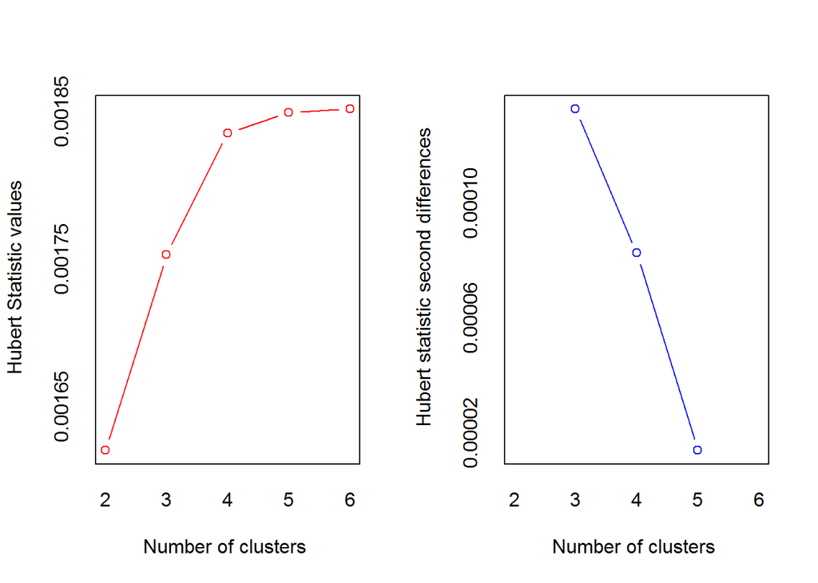

```
## *** : The Hubert index is a graphical method of determining the number of clusters.
##                 In the plot of Hubert index, we seek a significant knee that corresponds to a
##                 significant increase of the value of the measure i.e the significant peak in Hubert
##                 index second differences plot.
##
```

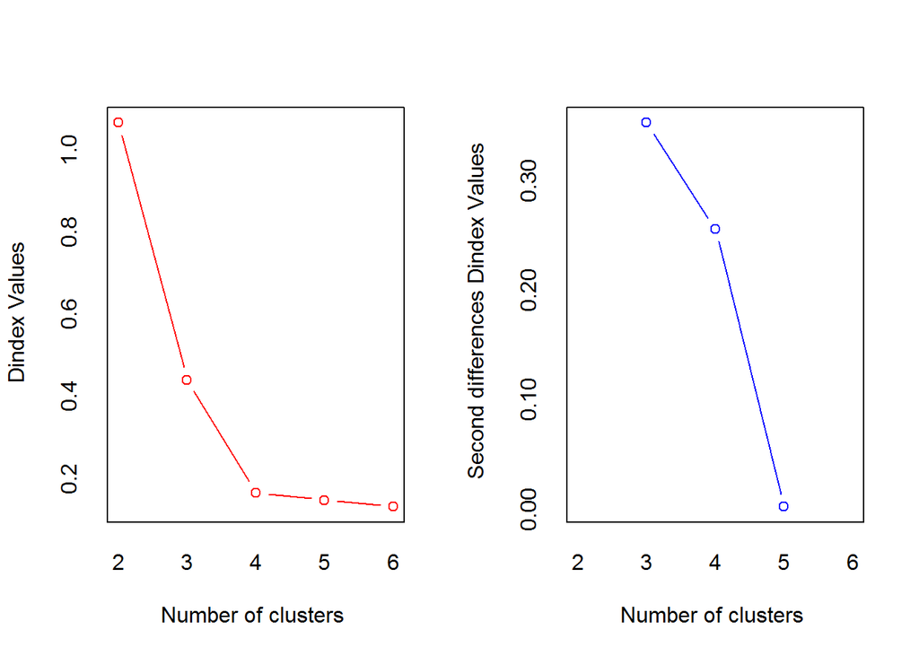

```
## *** : The D index is a graphical method of determining the number of clusters.
##                 In the plot of D index, we seek a significant knee (the significant peak in Dindex
##                 second differences plot) that corresponds to a significant increase of the value of
##                 the measure.
##
## * Among all indices:
## * 7 proposed 2 as the best number of clusters
## * 5 proposed 3 as the best number of clusters
## * 13 proposed 4 as the best number of clusters
## * 1 proposed 6 as the best number of clusters
##
##                    ***** Conclusion *****
##
## * According to the majority rule, the best number of clusters is  4
##
##
```

```r
set.seed(1)
x <- rbind(matrix(rnorm(20, sd = 0.1), ncol = 2),
           matrix(rnorm(20, mean = 1, sd = 0.2), ncol = 2),
           matrix(rnorm(20, mean = 5, sd = 0.1), ncol = 2),
           matrix(rnorm(20, mean = 7, sd = 0.2), ncol = 2))
diss_matrix <-  dist(x, method = "euclidean", diag = FALSE)
res <- NbClust(x, diss = diss_matrix, distance = NULL, min.nc = 2, max.nc = 6,
        method = "complete", index = "alllong")
```

```r
res$All.index
```

```
##        KL       CH Hartigan     CCC    Scott  Marriot TrCovW  TraceW
## 2  7.9990  447.811 136.9065 11.9651 137.8320 146.7611 2.6561 51.4968
## 3  2.5510 1070.124 223.8314 13.0324 201.4264  67.3481 0.5114 11.1881
## 4 59.1137 4965.892  12.5187 18.4692 304.1030   9.1919 0.5535  1.5871
## 5  1.2432 4883.169   9.8189 16.9714 326.5920   8.1857 0.4697  1.1776
## 6  2.0958 4861.459   6.9790 15.8757 346.8095   7.1106 0.3324  0.9196
##   Friedman     Rubin Cindex     DB Silhouette   Duda Pseudot2   Beale
## 2 1023.010   29.3249 0.3700 0.2764     0.8380 0.0210 838.6080 44.1373
## 3 1120.483  134.9769 0.3519 0.1335     0.8870 0.0699 239.3970 12.5998
## 4 2076.653  951.5190 0.2726 0.1986     0.8678 0.4471   9.8935  1.0993
## 5 2707.342 1282.4029 0.3165 0.4692     0.7469 0.5427   6.7421  0.7491
## 6 3515.091 1642.1697 0.3268 0.5444     0.6627 0.4792   6.5198  0.9314
##   Ratkowsky    Ball Ptbiserial    Gap   Frey McClain  Gamma  Gplus
## 2    0.6789 25.7484     0.9220 0.5352 1.7200  0.1667 1.0000 0.0000
## 3    0.5724  3.7294     0.8290 1.6018 2.1893  0.1730 1.0000 0.0000
## 4    0.4994  0.3968     0.6701 3.1798 6.7883  0.1399 1.0000 0.0000
## 5    0.4468  0.2355     0.6161 2.8963 5.2642  0.1524 0.9884 0.7244
## 6    0.4080  0.1533     0.5796 2.4222 7.8179  0.1578 0.9881 0.6833
##        Tau   Dunn Hubert SDindex Dindex   SDbw
## 2 194.8718 1.5955 0.0016  0.6943 1.0666 0.0784
## 3 179.4872 1.3155 0.0018  0.8993 0.4392 0.0125
## 4 138.4615 1.2067 0.0018  1.6575 0.1649 0.0026
## 5 123.3513 0.2498 0.0018  5.4795 0.1467 0.0020
## 6 113.5051 0.2934 0.0019  5.5902 0.1306 0.0016
```

```r
res$Best.nc
```

```
##                      KL       CH Hartigan     CCC    Scott Marriot TrCovW
## Number_clusters  4.0000    4.000   4.0000  4.0000   4.0000  4.0000 3.0000
## Value_Index     59.1137 4965.892 211.3126 18.4692 102.6765 57.1499 2.1448
##                  TraceW Friedman     Rubin Cindex     DB Silhouette   Duda
## Number_clusters  3.0000   4.0000    4.0000 4.0000 3.0000      3.000 4.0000
## Value_Index     30.7076 956.1706 -485.6583 0.2726 0.1335      0.887 0.4471
##                 PseudoT2  Beale Ratkowsky   Ball PtBiserial    Gap Frey
## Number_clusters       NA 4.0000    2.0000  3.000      2.000 4.0000   NA
## Value_Index           NA 1.0993    0.6789 22.019      0.922 3.1798   NA
##                 McClain Gamma Gplus      Tau   Dunn Hubert SDindex Dindex
## Number_clusters  4.0000     2     2   2.0000 2.0000      0  2.0000      0
## Value_Index      0.1399     1     0 194.8718 1.5955      0  0.6943      0
##                   SDbw
## Number_clusters 6.0000
## Value_Index     0.0016
```

```r
res$All.CriticalValues
```

```
##   CritValue_Duda CritValue_PseudoT2 Fvalue_Beale CritValue_Gap
## 2         0.1299           120.5893       0.0000       -1.0459
## 3         0.1299           120.5893       0.0001       -1.5525
## 4        -0.0987           -89.0644       0.3570        0.3178
## 5        -0.0987           -89.0644       0.4887        0.5237
## 6        -0.1908           -37.4469       0.4207        0.2581
```

```r
res$Best.partition
```

```
##  [1] 1 1 1 1 1 1 1 1 1 1 2 2 2 2 2 2 2 2 2 2 3 3 3 3 3 3 3 3 3 3 4 4 4 4 4
## [36] 4 4 4 4 4
```

#### Iris Data Set

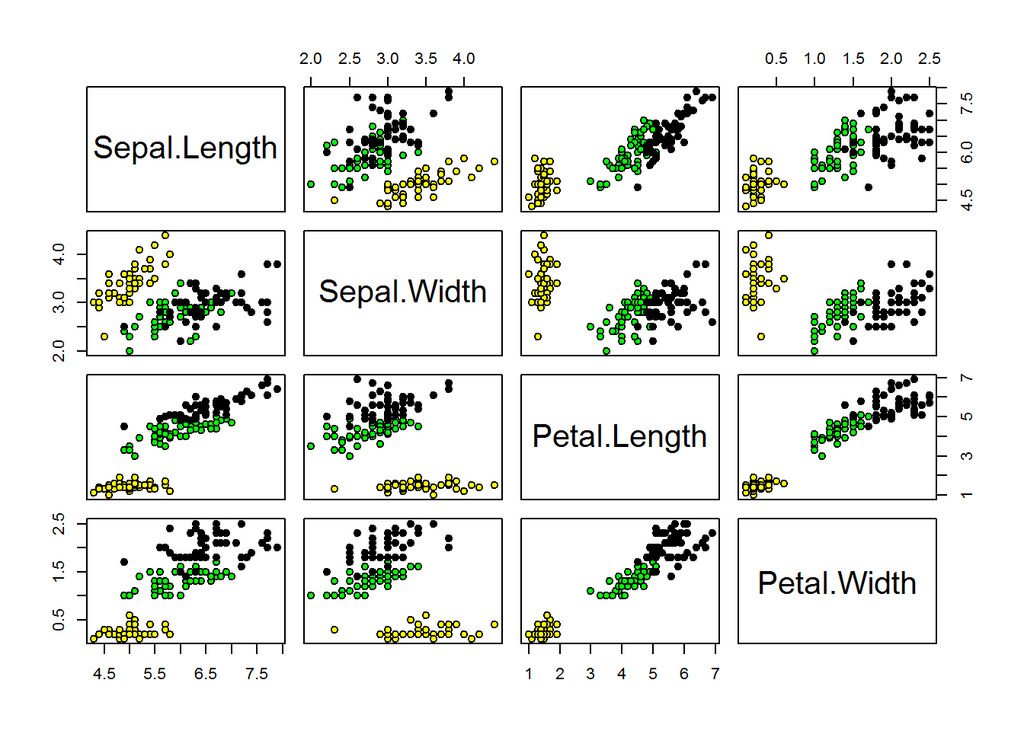

```r
# 4.2 Real data set

pairs(iris[, 1:4], bg = c("yellow", "green", "black")[iris$Species], pch = 21)
```

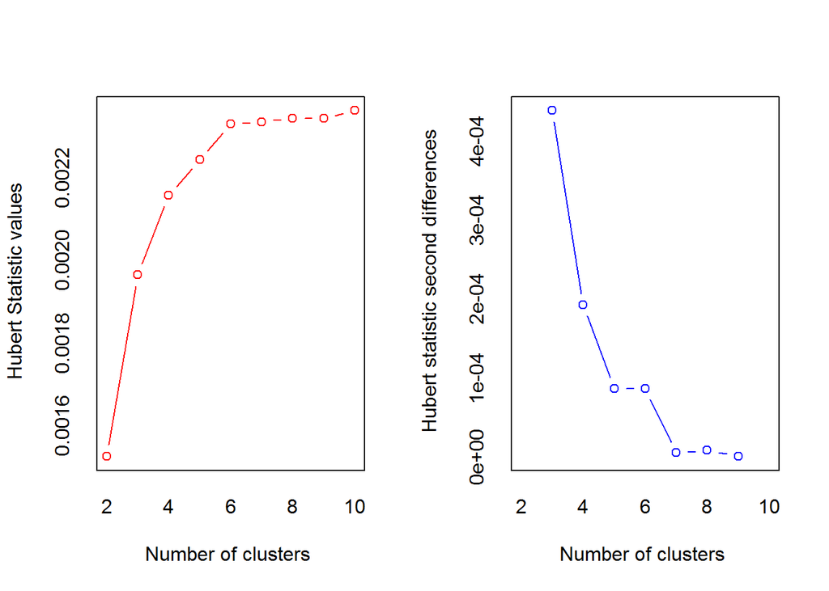

```
## *** : The Hubert index is a graphical method of determining the number of clusters.
##                 In the plot of Hubert index, we seek a significant knee that corresponds to a
##                 significant increase of the value of the measure i.e the significant peak in Hubert
##                 index second differences plot.
##
```

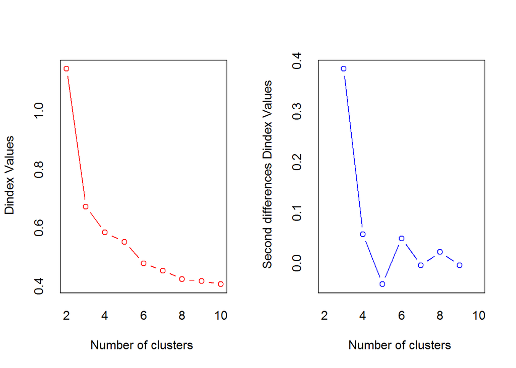

```
## *** : The D index is a graphical method of determining the number of clusters.
##                 In the plot of D index, we seek a significant knee (the significant peak in Dindex
##                 second differences plot) that corresponds to a significant increase of the value of
##                 the measure.
##
## * Among all indices:
## * 2 proposed 2 as the best number of clusters
## * 15 proposed 3 as the best number of clusters
## * 6 proposed 4 as the best number of clusters
## * 1 proposed 6 as the best number of clusters
## * 3 proposed 10 as the best number of clusters
##
##                    ***** Conclusion *****
##
## * According to the majority rule, the best number of clusters is  3
##
##
```

```r
data <- iris[, -5]
diss_matrix <-  dist(data, method = "euclidean", diag = FALSE)
res <- NbClust(data, diss = diss_matrix, distance = NULL, min.nc = 2, max.nc = 10,
               method = "complete", index = "alllong")
```

```r
res$All.index
```

```
##         KL       CH Hartigan     CCC     Scott  Marriot    TrCovW   TraceW
## 2   1.9652 280.8392 240.7478 30.4441  933.9084 977604.0 6868.5401 235.1531
## 3   5.3598 485.9050  68.8363 35.8668 1210.7629 347351.8  304.1791  89.5250
## 4  54.0377 495.1816  16.4167 35.6036 1346.7582 249402.3  135.7432  60.9730
## 5   0.0263 414.3925  51.1371 33.0698 1387.9419 296129.2  121.5044  54.8099
## 6   7.1653 455.4931  16.8076 33.9870 1506.5585 193380.9   96.9908  40.5198
## 7   0.5308 423.7198  20.2960 32.9063 1560.0089 184311.4   93.2005  36.2847
## 8   2.4071 414.7146   4.4653 32.4873 1628.7974 152185.5   60.9393  31.7749
## 9   6.5604 372.2046   8.2537 31.0319 1646.9164 170694.1   55.3030  30.8062
## 10  0.2708 348.6421   9.1553 30.1191 1680.9385 167969.1   55.2821  29.1026
##     Friedman    Rubin Cindex     DB Silhouette   Duda Pseudot2   Beale
## 2   715.2826  40.5663 0.3723 0.7027     0.5160 0.1460 444.4821 13.9360
## 3   804.1705 106.5545 0.3163 0.7025     0.5136 0.5582  55.4060  1.8840
## 4   955.5312 156.4512 0.3465 0.7289     0.4998 0.5932  32.9134  1.6216
## 5   991.9852 174.0431 0.3758 0.9838     0.3462 0.5452  48.3914  1.9801
```

[output cut: 25 more lines]

```r
res$Best.nc
```

```
##                      KL       CH Hartigan     CCC    Scott  Marriot
## Number_clusters  4.0000   4.0000   3.0000  3.0000   3.0000      3.0
## Value_Index     54.0377 495.1816 171.9115 35.8668 276.8545 532302.7
##                   TrCovW  TraceW Friedman    Rubin Cindex     DB
## Number_clusters    3.000   3.000   4.0000   6.0000 3.0000 3.0000
## Value_Index     6564.361 117.076 151.3607 -33.9014 0.3163 0.7025
##                 Silhouette   Duda PseudoT2 Beale Ratkowsky    Ball
## Number_clusters      2.000 4.0000   4.0000 3.000    3.0000  3.0000
## Value_Index          0.516 0.5932  32.9134 1.884    0.4922 87.7349
##                 PtBiserial    Gap Frey McClain  Gamma   Gplus     Tau
## Number_clusters     3.0000 3.0000    1  2.0000 4.0000 10.0000    3.00
## Value_Index         0.7203 0.1343   NA  0.4228 0.9261 52.7862 2649.84
##                    Dunn Hubert SDindex Dindex    SDbw
## Number_clusters 10.0000      0  3.0000      0 10.0000
## Value_Index      0.1543      0  1.6226      0  0.0303
```

```r
res$All.CriticalValues
```

```
##    CritValue_Duda CritValue_PseudoT2 Fvalue_Beale CritValue_Gap
## 2          0.6121            48.1694       0.0000       -0.3642
## 3          0.6027            46.1391       0.1134        0.2891
## 4          0.5551            38.4707       0.1704        0.2300
## 5          0.5800            42.0003       0.0983       -0.0305
## 6          0.4590            30.6444       0.1373        0.2590
## 7          0.5131            34.1652       0.2822        0.1346
## 8          0.4284            29.3527       1.0000        0.2635
## 9          0.2576            28.8239       0.2990        0.2483
## 10         0.3999            28.5079       0.3200        0.2200
```

```r
res$Best.partition
```

```
##   [1] 1 1 1 1 1 1 1 1 1 1 1 1 1 1 1 1 1 1 1 1 1 1 1 1 1 1 1 1 1 1 1 1 1 1 1
##  [36] 1 1 1 1 1 1 1 1 1 1 1 1 1 1 1 2 2 2 3 2 3 2 3 2 3 3 3 3 2 3 2 3 3 2 3
##  [71] 2 3 2 2 2 2 2 2 2 3 3 3 3 2 3 2 2 2 3 3 3 2 3 3 3 3 3 2 3 3 2 2 2 2 2
## [106] 2 3 2 2 2 2 2 2 2 2 2 2 2 2 2 2 2 2 2 2 2 2 2 2 2 2 2 2 2 2 2 2 2 2 2
## [141] 2 2 2 2 2 2 2 2 2 2
```

[Free Cluster PDF](http://www-users.cs.umn.edu/~kumar/dmbook/ch8.pdf)